# Sphagnum_regression_peat_tissue_respiration

We previously ran a basic FvCB tunned to Sphagnum that did NOT account for dead peat respiration.

Here, we look at correcting that by first using a linear regression model to estimate peat respiration from temperature using the cut chambers (those chambers that had live SPhagnum cut from them).

determine hetertrophic respiration as a linear regression of bare plots by temp

```
##
## Call:
## lm(formula = flux ~ temp)
##
## Residuals:
##     Min      1Q  Median      3Q     Max
## -2.4468 -0.1163 -0.0037  0.0836  4.4708
##
## Coefficients:
##             Estimate Std. Error t value Pr(>|t|)
## (Intercept) 0.171073   0.013904   12.30   <2e-16 ***
## temp        0.061759   0.001371   45.04   <2e-16 ***
## ---
## Signif. codes:  0 '***' 0.001 '**' 0.01 '*' 0.05 '.' 0.1 ' ' 1
##
## Residual standard error: 0.2501 on 1604 degrees of freedom
## Multiple R-squared:  0.5585, Adjusted R-squared:  0.5582
## F-statistic:  2029 on 1 and 1604 DF,  p-value: < 2.2e-16
```

Here is a plot of the predicted values from the observed for the cut bare plots for bar plot flux by predicted values

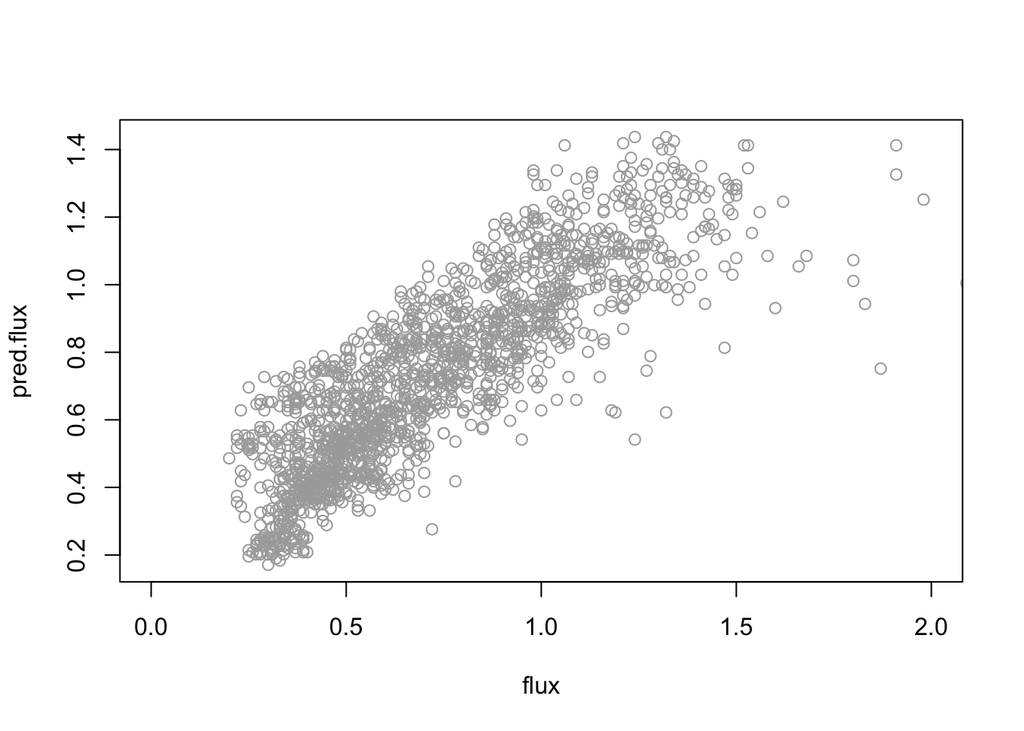

How does this compare to night time values for bare plots, and night time values for plots with live sphagnum?

First, the bare plots night temp vs. predcition values

```
##
## Call:
## lm(formula = flux.night ~ temp.night)
##
## Residuals:
##     Min      1Q  Median      3Q     Max
## -0.4050 -0.1109 -0.0347  0.0628  4.2444
##
## Coefficients:
##             Estimate Std. Error t value Pr(>|t|)
## (Intercept) 0.121286   0.027629    4.39 1.34e-05 ***
## temp.night  0.079023   0.003087   25.59  < 2e-16 ***
## ---
## Signif. codes:  0 '***' 0.001 '**' 0.01 '*' 0.05 '.' 0.1 ' ' 1
##
## Residual standard error: 0.3005 on 599 degrees of freedom
## Multiple R-squared:  0.5224, Adjusted R-squared:  0.5216
## F-statistic: 655.1 on 1 and 599 DF,  p-value: < 2.2e-16
```

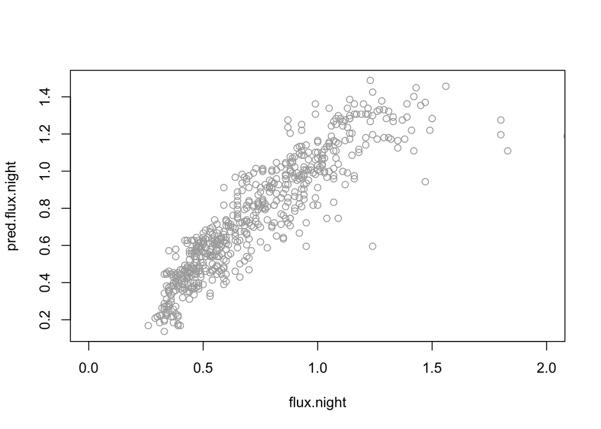

Now lets compare the predicted vlaues to night time chambers values with Sphagnum. this will have plant dark respiration values. Test with chamner 4

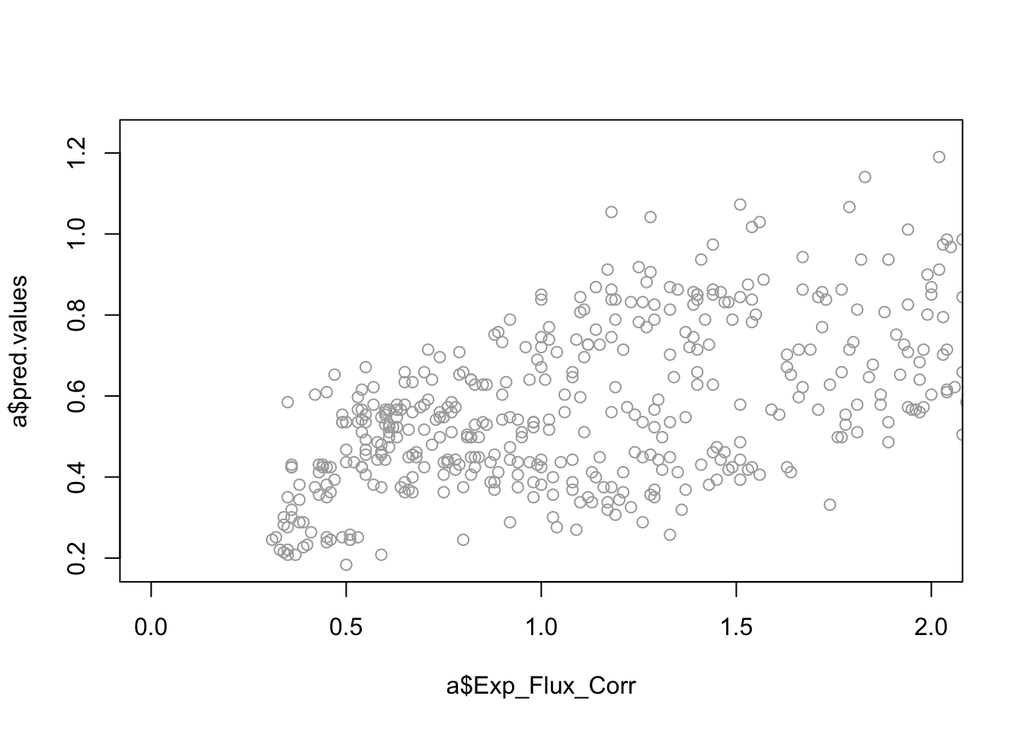

Now lets compare the predicted vlaues to night time chambers values with Sphagnum. this will have plant dark respiration values. Test with chamner 5

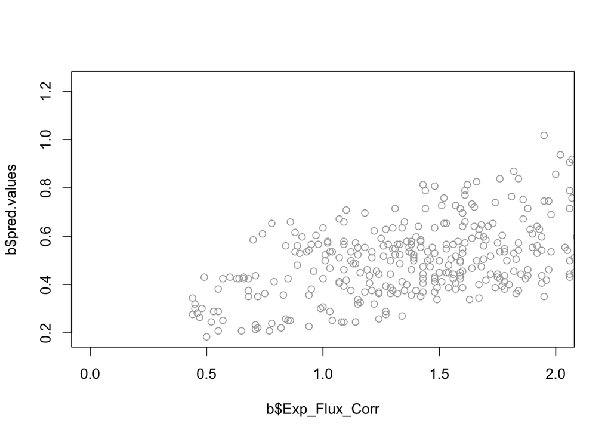

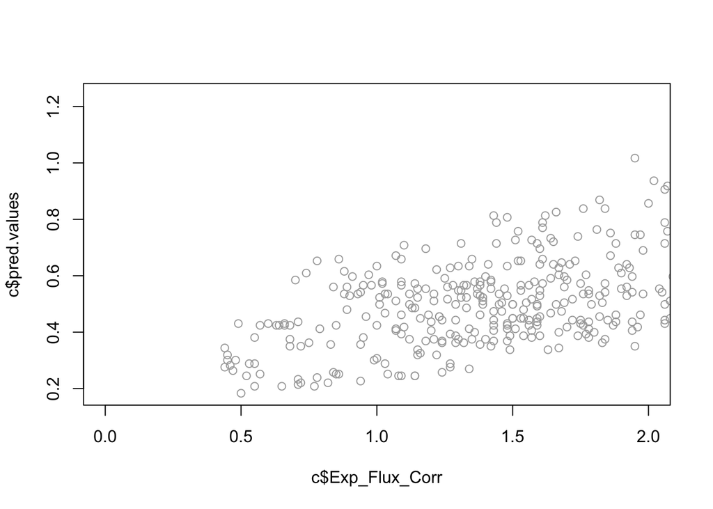